# Analiza cech pacjentów, które wpływają na wystąpienie udaru

Lab 10

Weronika Nadworska

## Cel badania

Światowe badania dowiodły, że udar jest drugą najczęstszą przyczyną zgonów na świecie. Pracując na wykorzystywanym zbiorze danych zawierającym różne informacje na temat pacjentów, takich jak płeć, wiek, występowanie chorób współistniejących czy bycie palaczem, postaram się zidentyfikować te cechy, które mają istotny wpływ na wystąpienie u nich udaru.

## Preprocessing

### Opis zbioru badawczego

Zbiór danych można znaleźć pod adresem https://www.kaggle.com/datasets/fedesoriano/stroke-prediction-dataset. Zawiera on dane 5110 pacjentów. Tabelka poniżej przedstawia kilka wierszy tego zbioru.

| id | gender | age | hypertension | heart_disease | ever_married | work_type | Residence_type | avg_glucose_level | bmi | smoking_status | stroke |
| --- | --- | --- | --- | --- | --- | --- | --- | --- | --- | --- | --- |
| 9046 | Male | 67 | 0 | 1 | Yes | Private | Urban | 228.69 | 36.6 | formerly smoked | 1 |
| 51676 | Female | 61 | 0 | 0 | Yes | Self-employed | Rural | 202.21 | NA | never smoked | 1 |
| 31112 | Male | 80 | 0 | 1 | Yes | Private | Rural | 105.92 | 32.5 | never smoked | 1 |
| 60182 | Female | 49 | 0 | 0 | Yes | Private | Urban | 171.23 | 34.4 | smokes | 1 |
| 1665 | Female | 79 | 1 | 0 | Yes | Self-employed | Rural | 174.12 | 24.0 | never smoked | 1 |
| 56669 | Male | 81 | 0 | 0 | Yes | Private | Urban | 186.21 | 29.0 | formerly smoked | 1 |

Jak możemy zauważyć, w zbiorze danych na temat pacjentów zostały przedstawione informacje na temat ich płci, wieku, czy chorują na nadciśnienie, czy mają choroby serca, czy byli kiedykolwiek w związku małżeńskim, jaki mają typ pracy, miejsce zamieszkania, średni poziom glukozy, wskaźnik BMI oraz tego, jak często palą papierosy. Zmienna `stroke` pokazuje, czy pacjent miał udar (wartość 1), czy nie (wartość 0).

### Statystyki opisowe dla zmiennych numerycznych

```
##       age        avg_glucose_level      bmi
##  Min.   : 0.08   Min.   : 55.12    Min.   :10.30
##  1st Qu.:25.00   1st Qu.: 77.25    1st Qu.:23.50
##  Median :45.00   Median : 91.89    Median :28.10
##  Mean   :43.23   Mean   :106.15    Mean   :28.89
##  3rd Qu.:61.00   3rd Qu.:114.09    3rd Qu.:33.10
##  Max.   :82.00   Max.   :271.74    Max.   :97.60
##                                    NA's   :201
```

Średni wiek (`age`) badanych pacjentów wynosi około 43 lata. Średni poziom glukozy (`avg_glucose_level`) przyjmuje wartości od 55.12 do 271,74 ze średnią wartością 106.14. Średnia wartość wskaźnika BMI (`bmi`) wynosi 28.89. W kolumnie tej występuje 201 braków danych.

### Liczby wystąpień poszczególnych poziomów dla zmiennych kategorycznych

|  | gender | hypertension | heart_disease | ever_married | work_type | Residence_type | smoking_status | stroke |
| --- | --- | --- | --- | --- | --- | --- | --- | --- |
|  | Female:2994 | 0:4612 | 0:4834 | No :1757 | Govt_job : 657 | Rural:2514 | formerly smoked: 885 | 0:4861 |
|  | Male :2115 | 1: 498 | 1: 276 | Yes:3353 | Never_worked : 22 | Urban:2596 | never smoked :1892 | 1: 249 |
|  | Other : 1 |  |  |  | Private :2925 |  | smokes : 789 |  |
|  |  |  |  |  | Self-employed: 819 |  | NA’s :1544 |  |
|  |  |  |  |  | children : 687 |  |  |  |

| stroke | n |
| --- | --- |
| 0 | 4860 |
| 1 | 249 |

Patrząc na zmienną `stroke` możemy zauważyć, że jedynie 249 pacjentów spośród 5110 przeszło udar. Liczba ta dość znacznie odbiega od liczby osób, które go nie przeszły. Może to mieć zły wpływ na niektóre analizy, ponieważ liczebność tych grup nie jest dobrze zbalansowana.

## Braki danych

Tabela poniżej przedstawia liczbę braków danych w poszczególnych kolumnach zbioru danych.

|  | Liczba braków |
| --- | --- |
| id | 0 |
| gender | 0 |
| age | 0 |
| hypertension | 0 |
| heart_disease | 0 |
| ever_married | 0 |
| work_type | 0 |
| Residence_type | 0 |
| avg_glucose_level | 0 |
| bmi | 201 |
| smoking_status | 1544 |
| stroke | 0 |

Jak widać, braki danych występują jedynie w kolumnach `bmi` oraz `smoking_status`. Pierwsza z nich jest kolumną liczbową i braki danych zostaną w niej zastąpione jej medianą. Druga jest zmienną kategoryczną i braki danych w niej występujące zostaną zastąpione wartością najczęściej występującą.

# Analiza dla zmiennych ilościowych

## Wiek (`age`)

Przedział ufności dla średniej wieku ma postać (29.21, 57.25), a dla wariancji (501.65, 521.49).

Poniżej przedstawione są statystyki opisowe w podziale ze względu na zmienną `stroke`.

| stroke | Mean | Var | Min | Q1 | sd | Q3 | Max | V | n |
| --- | --- | --- | --- | --- | --- | --- | --- | --- | --- |
| 0 | 41.97483 | 496.9804 | 0.08 | 24 | 22.29306 | 59 | 82 | 53.11053 | 4860 |
| 1 | 67.72819 | 161.9872 | 1.32 | 59 | 12.72742 | 78 | 82 | 18.79191 | 249 |

Z tabeli powyżej możemy zauważyć, że średnia wieku w grupie bez udaru wynosi około 42, a w grupie z udarem ponad 67. Dla grupy kontrolnej współczynnik zmienności wieku wynosi około 53%, czyli zmiennośc jest średnia. Dla grupy z udarem ta wartość wynoi niecałe 19%, a więc zmienność wieku jest mała w tej grupie.

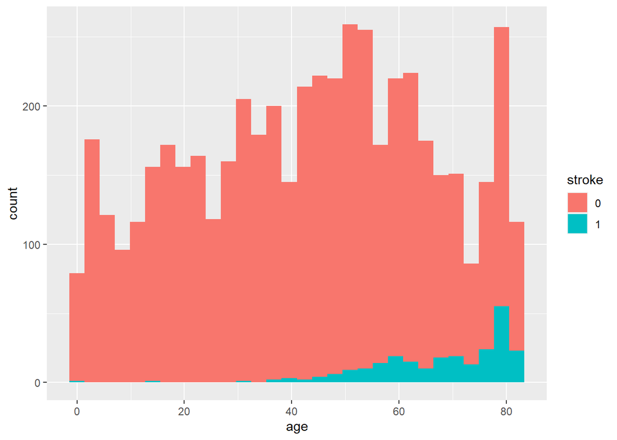

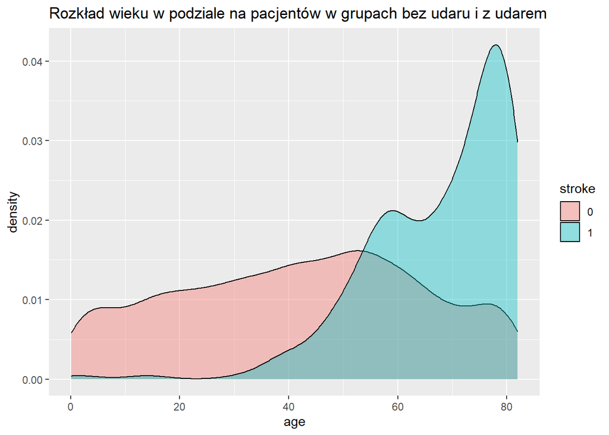

w grupie pacjentów z udarem częściej pojawiają się pacjenci starsi, niż ma to miejsce w grupie kontrolnej (bez udaru). Patrząc na wykres, można zauważyć, że dla grupy z udarem typowe wartości wieku zaczynają się od około 60 lat, podczas gdy dla grupy kontrolnej (control) typowy wiek mieści się w przedziale od 20 do 60.

Poniżej przedstawiony został test czy rozkład zmiennej `age` jest normalny w podziale na grupy pacjentów.

| stroke | statistic | p.value |
| --- | --- | --- |
| 0 | 0.9704635 | 0 |
| 1 | 0.8781332 | 0 |

W obu grupach wartość p-value jest bardzo bliska zeru, zatem należy odrzucić hipotezę o normalności rozkładu wieku w grupach.

Przeprowadzono również test o równości wariancji wieku w obu grupach.

$H_0$: Wariancja wieku jest taka sama dla pacjentów z udarem i bez udaru, $H_1$: Wariancja wieku jest różna dla pacjentów z udarem i bez udaru.

```
##
##  F test to compare two variances
##
## data:  dane[dane$stroke == 0, "age"] and dane[dane$stroke == 1, "age"]
## F = 3.068, num df = 4859, denom df = 248, p-value < 2.2e-16
## alternative hypothesis: true ratio of variances is not equal to 1
## 95 percent confidence interval:
##  2.541551 3.648661
## sample estimates:
## ratio of variances
##           3.068022
```

Odrzucamy hipotezę zerową na korzyść alternatywnej, zatem wariancje wieku pacjentów z udarem i bez udaru różnią się.

Odpowiednim testem do sprawdzenia hipotezy o równości średniej w obu grupach byłby test Manna-Whitneya, jednak powodu dużej liczebności próby zdecydowano się użyć jednak testu T, mimo braku normalności.

```
##
##  Welch Two Sample t-test
##
## data:  dane[dane$stroke == 0, "age"] and dane[dane$stroke == 1, "age"]
## t = -29.682, df = 331.68, p-value < 2.2e-16
## alternative hypothesis: true difference in means is not equal to 0
## 95 percent confidence interval:
##  -27.46015 -24.04658
## sample estimates:
## mean of x mean of y
##  41.97483  67.72819
```

P-value bardzo bliskie zeru, co sprowadza nas do odrzucienia hipotezy o równości średniej wieku w grupach pacjentów z udarem i bez udaru. Zatem wiek ma wpływ na przejście udaru przez pacjenta. Pacjenci starsi mają większą szansę na przejście udaru.

## Średni poziom glukozy (`avg_glucose_level`)

Przedział ufności dla średniej średniego poziomu glukozy ma postać (49.91, 162.37), a dla wariancji (2011.73, 2091.28).

Tabela poniżej przedstawia statystyki opisowe w podziale ze względu na zmienną `stroke`.

| stroke | Mean | Var | Min | Q1 | sd | Q3 | Max | V | n |
| --- | --- | --- | --- | --- | --- | --- | --- | --- | --- |
| 0 | 104.7876 | 1922.568 | 55.12 | 77.12 | 43.84709 | 112.80 | 267.76 | 41.84379 | 4860 |
| 1 | 132.5447 | 3834.217 | 56.11 | 79.79 | 61.92106 | 196.71 | 271.74 | 46.71710 | 249 |

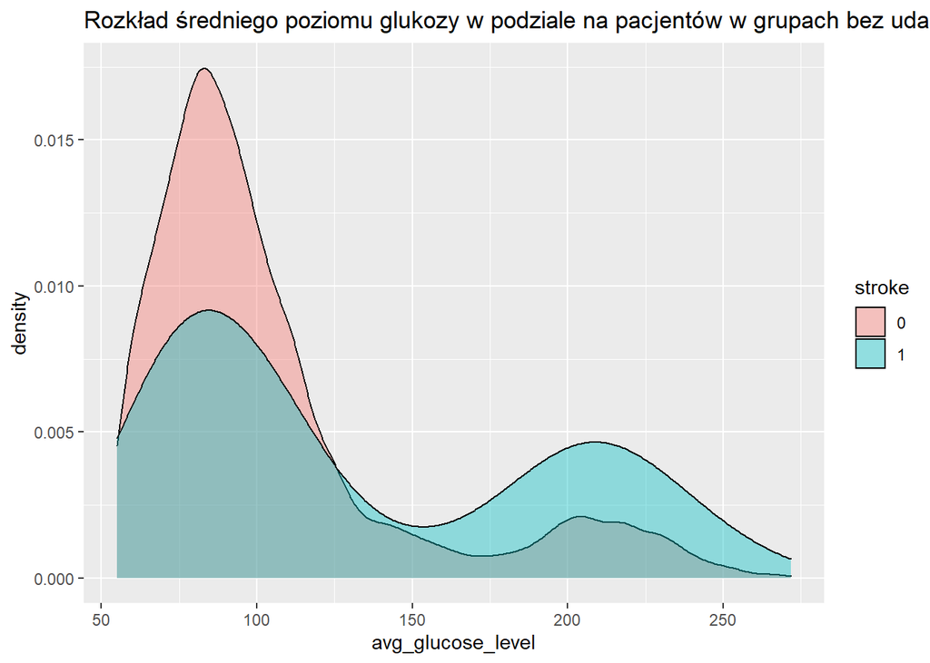

Patrząc na powyższy wykres, możemy zauważyć, że w grupie pacjentów, którzy nie przeszli udaru częściej pojawiają się pacjenci ze średnim niższym poziomem cukru. Z wykresu gęstości wynika również, że średnio osoby, które przeszły udar miały nieco wyższy średni poziom glukozy.

Poniżej przeprowadzony został test czy rozkład zmiennej `avg_glucose_level` jest normalny w podziale na grupy pacjentów.

| stroke | statistic | p.value |
| --- | --- | --- |
| 0 | 0.8034937 | 0 |
| 1 | 0.8712363 | 0 |

W obu grupach wartość p-value jest bardzo bliska zeru, zatem należy odrzucić hipotezę o normalności rozkładu średniego poziomu glukozy w grupach.

Przeprowadzono również test o równości wariancji tej cechy w obu grupach.

$H_0$: Wariancja średniego poziomu glukozy jest taka sama dla pacjentów z udarem i bez udaru, $H_1$: Wariancja średniego poziomu glukozy jest różna dla pacjentów z udarem i bez udaru.

```
##
##  F test to compare two variances
##
## data:  dane[dane$stroke == 0, "avg_glucose_level"] and dane[dane$stroke == 1, "avg_glucose_level"]
## F = 0.50142, num df = 4859, denom df = 248, p-value < 2.2e-16
## alternative hypothesis: true ratio of variances is not equal to 1
## 95 percent confidence interval:
##  0.4153797 0.5963207
## sample estimates:
## ratio of variances
##          0.5014238
```

Wartość p-value bardzo bliska 0, zatem odrzucamy hipotezę zerową na korzyść hipotezy alternatywnej. Stąd wariancje średniego poziomu cukru pacjentów z udarem i bez udaru różnią się.

Przeprowadzono również test T aby sprawdzić hipotezy o równości średniej w obu grupach.

```
##
##  Welch Two Sample t-test
##
## data:  dane[dane$stroke == 0, "avg_glucose_level"] and dane[dane$stroke == 1, "avg_glucose_level"]
## t = -6.9844, df = 260.9, p-value = 2.373e-11
## alternative hypothesis: true difference in means is not equal to 0
## 95 percent confidence interval:
##  -35.58269 -19.93162
## sample estimates:
## mean of x mean of y
##  104.7876  132.5447
```

Test odrzuca hipotezę o równości średnich poziomów glukozy u pacjentów z udarem i bez udaru.

## BMI

Przedział ufności dla średniej warrości współczynnika BMI ma postać (27.24, 30.49), a dla wariancji (58.16, 60.46).

Tabela poniżej przedstawia statystyki opisowe w podziale ze względu na zmienną `stroke`.

| stroke | Mean | Var | Min | Q1 | sd | Q3 | Max | V | n |
| --- | --- | --- | --- | --- | --- | --- | --- | --- | --- |
| 0 | 28.80043 | 60.48994 | 10.3 | 23.6 | 7.777528 | 32.8 | 97.6 | 27.00490 | 4860 |
| 1 | 30.09036 | 34.36160 | 16.9 | 27.0 | 5.861877 | 32.5 | 56.6 | 19.48091 | 249 |

[figure not shown]

Poniższy wykres boxplot również pozwala zauważyć, że wartość współczynnika BMI jest zbliżona w obu grupach. Sporo jest wartości odstajacych w grupie osób, które nie przeszły udaru. Wartości mediany są bardzo zbliżone.

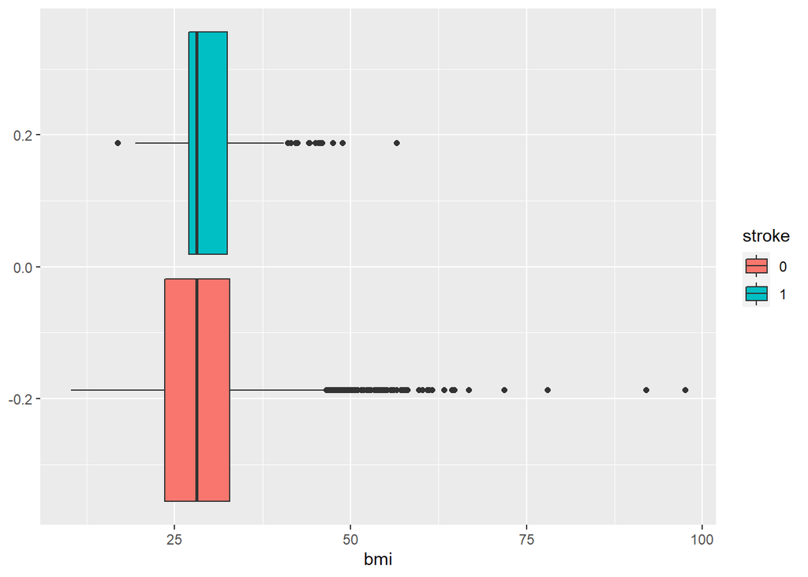

Przeprowadzimy test sprawdzajacy czy rozkład badanej zmiennej jest normalny w podziale na grupy pacjentów.

| stroke | statistic | p.value |
| --- | --- | --- |
| 0 | 0.9503380 | 0 |
| 1 | 0.9248189 | 0 |

Wartosć p-value jest bardzo bliska zeru. Zatem rozkład wskaźnieka BMI w podziale na pacjentów z udarem i bez nie jest rozkładem normalnym.

Sprawdzimy teraz hipotezę o równości wariancji w obu grupach.

$H_0$: Wariancja wskaźnieka BMI jest taka sama dla pacjentów z udarem i bez udaru, $H_1$: Wariancja wskaźnieka BMI jest różna dla pacjentów z udarem i bez udaru.

```
##
##  F test to compare two variances
##
## data:  dane[dane$stroke == 0, "bmi"] and dane[dane$stroke == 1, "bmi"]
## F = 1.7604, num df = 4859, denom df = 248, p-value = 1.836e-08
## alternative hypothesis: true ratio of variances is not equal to 1
## 95 percent confidence interval:
##  1.458311 2.093557
## sample estimates:
## ratio of variances
##           1.760394
```

Testem T sprawdzimy hipotezy o równości średniej w obu grupach.

```
##
##  Welch Two Sample t-test
##
## data:  dane[dane$stroke == 0, "bmi"] and dane[dane$stroke == 1, "bmi"]
## t = -3.3257, df = 294.63, p-value = 0.0009938
## alternative hypothesis: true difference in means is not equal to 0
## 95 percent confidence interval:
##  -2.053281 -0.526578
## sample estimates:
## mean of x mean of y
##  28.80043  30.09036
```

P-value biskie zeru, zatem średnia wartosć wskaźnieka BMI nie jest taka sama w obu grupach. Pacjenci z wyższym wskaźnikiem BMI mogą mieć większą szansę na przejście udaru.

# Analiza dla zmiennych kategorycznych

### Nadciśnienie

Przedział ufności dla frakcji pacjentów z nadciśnieniem w całym zbiorze danych ma postać (0.09, 0.11). Takich pacjentów jest więc około 9-10 procent w całym zbiorze danych.

Tabela ponizej przedstawia procentowy udział poszczególnych poziomów badanej zmiennej w grupach z udarem i bez udaru.

| Hypertension | Stroke 0 | Stroke 1 |
| --- | --- | --- |
| 0 | 91.1 | 73.5 |
| 1 | 8.9 | 26.5 |

Zatem pacjentów, którzy mają nadciśnienie (`hypertension`) i przeszli udar jest 26.5%, zaś tych, którzy nie mają tej choroby i przeszli udar jest 73.5%.

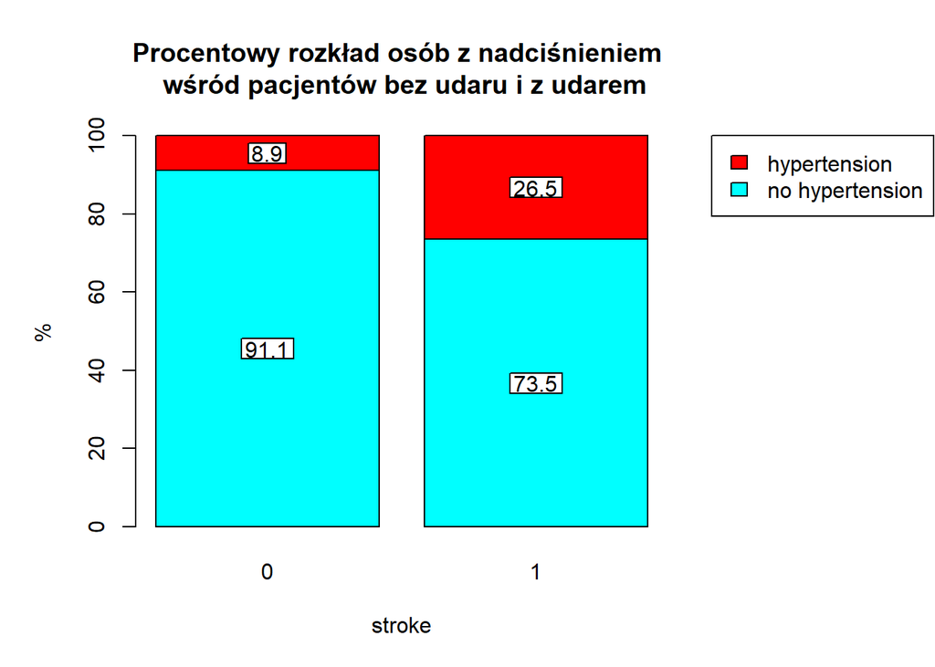

Wykres powyżej przedstawia rozkład poszczególnych poziomów zmiennej `hypertension` w podziale na pacjentów z udarem i bez. W grupie bez udaru pacjenci z nadciśnieniem stanowią niecałe 9%. Wśród pacjentów z udarem chorzy na nadciśnienie stanowią 26.5% grupy. Odsetek pacjentów z nadciśnieniem wydaje się więc wyższy w grupie pacjentów z udarem.

Przeprowadzimy test mający na celu sprawdzenie, czy proporcja osób chorych na nadciśnienie jest taka sama w grupach z udarem i bez.

Niech $p_1$ - frakcja osób z nadciśnieniem w grupie bez udaru, $p_2$ - frakcja osób z nadciśnieniem w grupie z udarem. Testujemy hipotezy: $H_0: p_1 = p_2$, $H_1: p_1 < p_2$.

Statystyka testowa ma wartość -9.14. Zbiór krytyczny ma postać $(-\infty, -$ 1.96 $]$. Statystyka testowa należy do zbioru krytycznego. Zatem odrzucamy hipotezę zerową na korzyść alternatywnej. Stąd odsetek pacjentów z nadciśnieniem jest istotnie większy w grupie z udarem niż bez udaru.

### Choroby serca

Tabela ponizej przedstawia procentowy udział poszczególnych poziomów badanej zmiennej w grupach z udarem i bez udaru.

| Heart_disease | Stroke 0 | Stroke 1 |
| --- | --- | --- |
| 0 | 95.3 | 81.1 |
| 1 | 4.7 | 18.9 |

Zatem pacjentów, którzy mają choroby serca (`heart_desease`) i przeszli udar jest niecałe 19%, zaś tych, którzy nie mają problemów z sercem i przeszli udar jest około 81%.

[figure not shown]

Wykres powyżej przedstawia rozkład poszczególnych poziomów zmiennej `heart_desease` w podziale na pacjentów z udarem i bez. W grupie bez udaru pacjenci z chorobami serca stanowią niecałe 5%. Wśród pacjentów z udarem tacy pacjenci stanowią prawie 19% grupy. Odsetek pacjentów z chorobami serca wydaje się więc być wyższy w grupie pacjentów z udarem.

Przeprowadzimy test mający na celu sprawdzenie, czy proporcja osób posiadających choroby serca jest taka sama w grupach z udarem i bez.

Niech $p_1$ - frakcja osób posiadających choroby serca w grupie bez udaru, $p_2$ - frakcja osób nie mających chorób serca w grupie z udarem. Testujemy hipotezy: $H_0: p_1 = p_2$ $H_1: p_1 < p_2$

Statystyka testowa ma wartość -9.64. Zbiór krytyczny ma postać $(-\infty, -$ 1.96 $]$. Statystyka testowa należy do zbioru krytycznego. Zatem odrzucamy hipotezę zerową na korzyść alternatywnej. Stąd odsetek pacjentów z chorobami serca jest istotnie większy w grupie z udarem niż bez udaru.

### Będący kiedykowiek w związku małżeńskim

Przedział ufności dla frakcji pacjentów będących kiedykolwiek w związku małżeńskim w całym zbiorze danych ma postać (0.64, 0.67). Takich pacjentów jest więc około 64-67% w całym zbiorze danych.

Tabela ponizej przedstawia procentowy udział poszczególnych poziomów badanej zmiennej w grupach z udarem i bez udaru.

| Ever_married | Stroke 0 | Stroke 1 |
| --- | --- | --- |
| No | 36 | 12 |
| Yes | 64 | 88 |

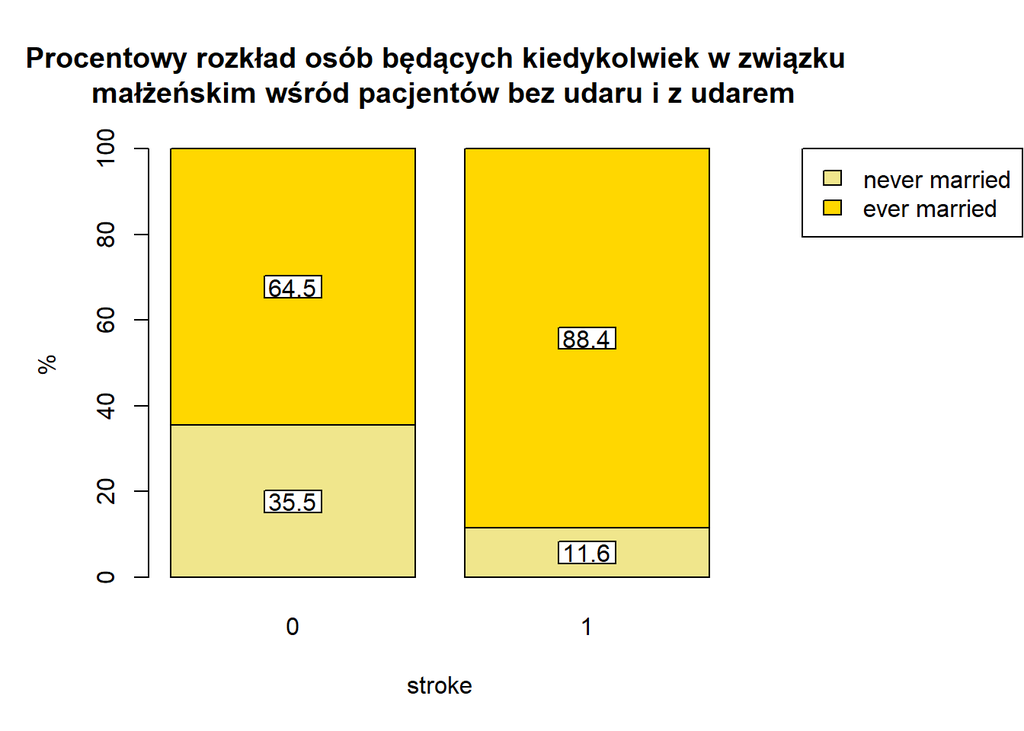

Wykres powyżej przedstawia rozkład poszczególnych poziomów zmiennej `ever_married` w podziale na pacjentów z udarem i bez. W grupie bez udaru pacjenci z kiedykolwiek będący w zwiazku małżeńskim stanowią prawie 65%. Wśród pacjentów z udarem tacy pacjenci stanowią prawie 90% grupy.

Przeprowadzimy test mający na celu sprawdzenie, czy proporcja osób kiedykolwiek będacych w zwiazku małżeńskim jest taka sama w grupach z udarem i bez.

Niech $p_1$ - frakcja osób będacych kiedykolwiek w zwiazku małżeńskim w grupie bez udaru, $p_2$ - frakcja osób nie będacych kiedykolwiek w zwiazku małżeńskim w grupie z udarem. Testujemy hipotezy: $H_0: p_1 = p_2$, $H_1: p_1 < p_2$.

Statystyka testowa ma wartość -7.74. Zbiór krytyczny ma postać $(-\infty, -$ 1.96 $]$. Statystyka testowa należy do zbioru krytycznego. Zatem hipotezę zerową na korzyść alternatywnej. Stąd odsetek pacjentów będących kiedykolwiek w zwiazku małżeńskim jest większy w grupie z udarem niż bez udaru.

### Miejsce zamieszkania

Przedział ufności dla frakcji pacjentów zamieszkałych w mieście w całym zbiorze danych ma postać (0.49, 0.52). Takich pacjentów jest więc około 49-52% w całym zbiorze danych.

Tabela ponizej przedstawia procentowy udział poszczególnych poziomów badanej zmiennej w grupach z udarem i bez udaru.

| Residence_tyoe | Stroke 0 | Stroke 1 |
| --- | --- | --- |
| Rural | 49 | 46 |
| Urban | 51 | 54 |

Zatem liczba pacjentów zamieszkałych w mieście, jak i na wsi, zarówno tych, którzy przeszli udar, jak i nie, wynosi około 50% w obu grupach.

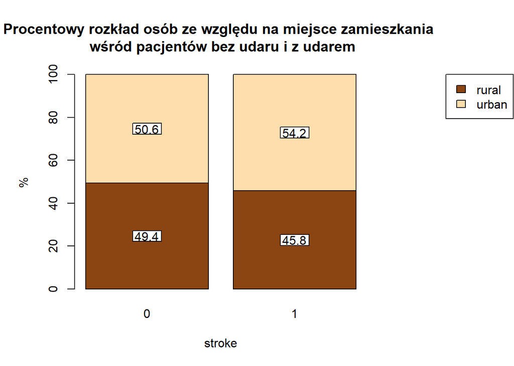

Wykres powyżej przedstawia rozkład poszczególnych poziomów zmiennej `Residence_type` w podziale na pacjentów z udarem i bez.

Przeprowadzimy test mający na celu sprawdzenie, czy proporcja osób mieszkajacych w mieście jest taka sama w grupach z udarem i bez.

### Typ pracy

Przedział ufności dla frakcji pacjentów będących dziecmi w całym zbiorze danych ma postać (0.13, 0.14). Takich pacjentów jest więc około 13-14% w całym zbiorze danych.

Tabela ponizej przedstawia procentowy udział poszczególnych poziomów badanej zmiennej w grupach z udarem i bez udaru.

| Work_type | Stroke 0 | Stroke 1 |
| --- | --- | --- |
| Govt_job | 12.84 | 13.25 |
| Never_worked | 0.45 | 0.00 |
| Private | 57.10 | 59.84 |
| Self-employed | 15.51 | 26.10 |
| children | 14.09 | 0.80 |

[figure not shown]

Wykres powyżej przedstawia rozkład poszczególnych poziomów zmiennej `work_type` w podziale na pacjentów z udarem i bez.

Przeprowadzimy test mający na celu sprawdzenie, czy proporcja osób samozatrudnionych jest taka sama w grupach z udarem i bez.

Niech $p_1$ - frakcja osób samozatrudnionych w grupie bez udaru, $p_2$ - frakcja osób samozatrudnionych w grupie z udarem. Testujemy hipotezy: $H_0: p_1 = p_2$, $H_1: p_1 < p_2$.

Statystyka testowa ma wartość -4.44. Zbiór krytyczny ma postać $(-\infty, -$ 1.96 $]$. Statystyka testowa należy do zbioru krytycznego. Zatem hipotezę zerową na korzyść alternatywnej. Stąd odsetek pacjentów zamozatrudnionych jest większy w grupie z udarem niż bez udaru.

### Częstość palenia papierosów

Tabela ponizej przedstawia procentowy udział poszczególnych poziomów badanej zmiennej w grupach z udarem i bez udaru.

| Smoking_status | Stroke 0 | Stroke 1 |
| --- | --- | --- |
| formerly smoked | 28 | 35 |
| never smoked | 55 | 47 |
| smokes | 17 | 18 |

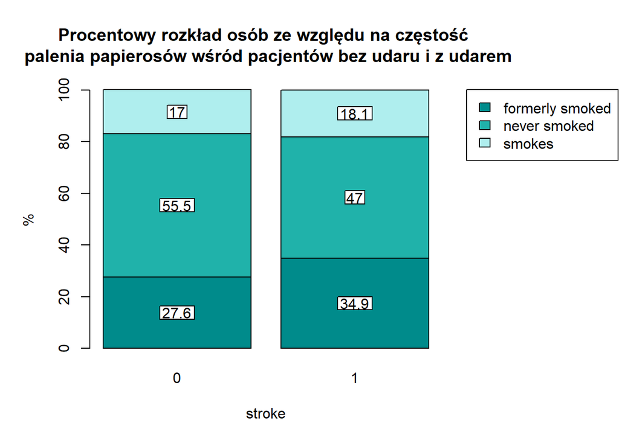

Przeprowadzimy test mający na celu sprawdzenie, czy proporcja osób palących papierosy jest taka sama w grupach z udarem i bez.

Niech $p_1$ - frakcja osób palących w grupie bez udaru, $p_2$ - frakcja osób palących w grupie z udarem. Testujemy hipotezy: $H_0: p_1 = p_2$, $H_1: p_1 < p_2$.

Statystyka testowa ma wartość -0.44. Zbiór krytyczny ma postać $(-\infty, -$ 1.96 $]$. Statystyka testowa nie należy do zbioru krytycznego. Zatem nie mamy podstaw do odrzucenia hipotezy zerowej. Stąd odsetek pacjentów palących papierosy jest zbliżony w grupie z udarem i bez udaru.

### Płeć

Przedział ufności dla frakcji pacjentów będących mężczyznami w całym zbiorze danych ma postać (0.4, 0.43). Takich pacjentów jest więc około 40-43% w całym zbiorze danych.

Tabela poniżej przedstawia procentowy udział poszczególnych poziomów badanej zmiennej w grupach z udarem i bez udaru.

| Gender | Stroke 0 | Stroke 1 |
| --- | --- | --- |
| Female | 59 | 57 |
| Male | 41 | 43 |

[figure not shown]

Wykres powyżej przedstawia rozkład poszczególnych poziomów zmiennej `gender` w podziale na pacjentów z udarem i bez. W grupie bez udaru pacjenci będący mężczyznami stanowią nieco ponad 41%. Wśród pacjentów z udarem tacy pacjenci stanowią 43.4% grupy.

Przeprowadzimy test mający na celu sprawdzenie, czy proporcja osób będących mężczyznami jest taka sama w grupach z udarem i bez.

# Wnioski